# Part I - (Dataset Exploration Title)

```python
#checking for insights of the Dataset
new_df.describe()
```

|  | MonthlyLoanPayment | LoanCurrentDaysDelinquent | StatedMonthlyIncome | LoanOriginalAmount | Term | Investors | LenderYield | ProsperRating (numeric) | ProsperScore | ListingCategory (numeric) | CurrentDelinquencies | AmountDelinquent | DelinquenciesLast7Years | TotalProsperLoans | OnTimeProsperPayments | BorrowerAPR | BorrowerRate | LenderYield |
| --- | --- | --- | --- | --- | --- | --- | --- | --- | --- | --- | --- | --- | --- | --- | --- | --- | --- | --- |
| count | 19771.000000 | 19771.000000 | 19771.000000 | 19771.000000 | 19771.000000 | 19771.000000 | 19771.000000 | 19771.000000 | 19771.000000 | 19771.000000 | 19771.000000 | 19771.000000 | 19771.000000 | 19771.000000 | 19771.000000 | 19771.000000 | 19771.000000 | 19771.000000 |
| mean | 253.909037 | 42.164079 | 5948.948742 | 7874.633908 | 42.245511 | 78.670528 | 0.181298 | 4.194274 | 6.172323 | 3.679885 | 0.425826 | 1229.687016 | 3.631733 | 1.460118 | 23.582823 | 0.220972 | 0.191303 | 0.181298 |
| std | 162.908231 | 158.102012 | 4294.163582 | 5405.165934 | 11.754228 | 89.672636 | 0.077868 | 1.706970 | 2.712603 | 4.567888 | 1.347884 | 7976.837006 | 8.938246 | 0.788810 | 19.334022 | 0.082770 | 0.077874 | 0.077868 |
| min | 0.000000 | 0.000000 | 0.000000 | 1000.000000 | 12.000000 | 1.000000 | 0.030000 | 1.000000 | 1.000000 | 0.000000 | 0.000000 | 0.000000 | 0.000000 | 0.000000 | 0.000000 | 0.045830 | 0.040000 | 0.030000 |
| 25% | 130.945000 | 0.000000 | 3478.375000 | 4000.000000 | 36.000000 | 10.000000 | 0.116900 | 3.000000 | 4.000000 | 1.000000 | 0.000000 | 0.000000 | 0.000000 | 1.000000 | 9.000000 | 0.153240 | 0.126900 | 0.116900 |
| 50% | 214.980000 | 0.000000 | 5000.000000 | 6500.000000 | 36.000000 | 49.000000 | 0.174500 | 4.000000 | 6.000000 | 1.000000 | 0.000000 | 0.000000 | 0.000000 | 1.000000 | 17.000000 | 0.214740 | 0.184500 | 0.174500 |
| 75% | 346.320000 | 0.000000 | 7250.000000 | 11000.000000 | 60.000000 | 114.000000 | 0.244900 | 6.000000 | 8.000000 | 6.000000 | 0.000000 | 0.000000 | 2.000000 | 2.000000 | 34.000000 | 0.287040 | 0.254900 | 0.244900 |
| max | 2134.060000 | 1540.000000 | 150000.000000 | 35000.000000 | 60.000000 | 899.000000 | 0.340000 | 7.000000 | 11.000000 | 20.000000 | 27.000000 | 284169.000000 | 99.000000 | 8.000000 | 141.000000 | 0.413550 | 0.360000 | 0.340000 |

```python
#checking for correlation
new_df.corr()
```

|  | MonthlyLoanPayment | LoanCurrentDaysDelinquent | StatedMonthlyIncome | LoanOriginalAmount | Term | Investors | LenderYield | ProsperRating (numeric) | ProsperScore | ListingCategory (numeric) | IsBorrowerHomeowner | CurrentDelinquencies | AmountDelinquent | DelinquenciesLast7Years | TotalProsperLoans | OnTimeProsperPayments | BorrowerAPR | BorrowerRate | LenderYield |
| --- | --- | --- | --- | --- | --- | --- | --- | --- | --- | --- | --- | --- | --- | --- | --- | --- | --- | --- | --- |
| MonthlyLoanPayment | 1.000000 | -0.055845 | 0.310249 | 0.901150 | 0.045834 | 0.397710 | -0.237650 | 0.255252 | 0.137001 | -0.161596 | 0.106782 | -0.097906 | -0.014969 | -0.076809 | 0.037550 | 0.019717 | -0.229530 | -0.237696 | -0.237650 |
| LoanCurrentDaysDelinquent | -0.055845 | 1.000000 | -0.074403 | -0.090149 | -0.039622 | -0.004066 | 0.229315 | -0.206485 | -0.144548 | -0.016352 | -0.028191 | 0.084253 | 0.015001 | 0.024795 | -0.051582 | -0.031481 | 0.221034 | 0.229377 | 0.229315 |
| StatedMonthlyIncome | 0.310249 | -0.074403 | 1.000000 | 0.319076 | 0.018645 | 0.132883 | -0.175615 | 0.182851 | 0.149444 | -0.030138 | 0.220641 | -0.023546 | 0.023840 | -0.024594 | 0.020138 | -0.004610 | -0.178276 | -0.175605 | -0.175615 |
| LoanOriginalAmount | 0.901150 | -0.090149 | 0.319076 | 1.000000 | 0.343459 | 0.430871 | -0.332352 | 0.378494 | 0.265946 | -0.159308 | 0.128464 | -0.120805 | -0.024834 | -0.094431 | 0.051314 | 0.012975 | -0.348620 | -0.332394 | -0.332352 |
| Term | 0.045834 | -0.039622 | 0.018645 | 0.343459 | 1.000000 | 0.035051 | 0.046929 | 0.064888 | 0.021336 | -0.024893 | 0.041590 | -0.038608 | -0.012256 | -0.015174 | 0.046178 | -0.033133 | -0.018272 | 0.046891 | 0.046929 |
| Investors | 0.397710 | -0.004066 | 0.132883 | 0.430871 | 0.035051 | 1.000000 | -0.272758 | 0.309903 | 0.243873 | -0.099637 | 0.090321 | -0.084923 | -0.014325 | -0.084070 | -0.014729 | -0.022225 | -0.294236 | -0.272751 | -0.272758 |
| LenderYield | -0.237650 | 0.229315 | -0.175615 | -0.332352 | 0.046929 | -0.272758 | 1.000000 | -0.952346 | -0.754927 | -0.001722 | -0.103161 | 0.192588 | 0.058338 | 0.161547 | -0.053791 | 0.003134 | 0.993018 | 0.999996 | 1.000000 |
| ProsperRating (numeric) | 0.255252 | -0.206485 | 0.182851 | 0.378494 | 0.064888 | 0.309903 | -0.952346 | 1.000000 | 0.757645 | -0.004901 | 0.116415 | -0.191651 | -0.058092 | -0.160661 | 0.046683 | -0.017253 | -0.961410 | -0.952333 | -0.952346 |
| ProsperScore | 0.137001 | -0.144548 | 0.149444 | 0.265946 | 0.021336 | 0.243873 | -0.754927 | 0.757645 | 1.000000 | -0.027095 | 0.018841 | -0.180713 | -0.069149 | -0.134610 | 0.069698 | 0.060527 | -0.774692 | -0.754859 | -0.754927 |
| ListingCategory (numeric) | -0.161596 | -0.016352 | -0.030138 | -0.159308 | -0.024893 | -0.099637 | -0.001722 | -0.004901 | -0.027095 | 1.000000 | -0.066313 | 0.042999 | 0.019100 | 0.048824 | -0.004084 | -0.019638 | 0.005698 | -0.001742 | -0.001722 |
| IsBorrowerHomeowner | 0.106782 | -0.028191 | 0.220641 | 0.128464 | 0.041590 | 0.090321 | -0.103161 | 0.116415 | 0.018841 | -0.066313 | 1.000000 | 0.032854 | 0.067981 | 0.003413 | 0.016618 | 0.006046 | -0.109866 | -0.103210 | -0.103161 |
| CurrentDelinquencies | -0.097906 | 0.084253 | -0.023546 | -0.120805 | -0.038608 | -0.084923 | 0.192588 | -0.191651 | -0.180713 | 0.042999 | 0.032854 | 1.000000 | 0.429208 | 0.421656 | 0.001249 | 0.045602 | 0.196828 | 0.192583 | 0.192588 |
| AmountDelinquent | -0.014969 | 0.015001 | 0.023840 | -0.024834 | -0.012256 | -0.014325 | 0.058338 | -0.058092 | -0.069149 | 0.019100 | 0.067981 | 0.429208 | 1.000000 | 0.318133 | 0.001770 | 0.021627 | 0.061972 | 0.058333 | 0.058338 |
| DelinquenciesLast7Years | -0.076809 | 0.024795 | -0.024594 | -0.094431 | -0.015174 | -0.084070 | 0.161547 | -0.160661 | -0.134610 | 0.048824 | 0.003413 | 0.421656 | 0.318133 | 1.000000 | -0.025969 | 0.012283 | 0.165792 | 0.161521 | 0.161547 |
| TotalProsperLoans | 0.037550 | -0.051582 | 0.020138 | 0.051314 | 0.046178 | -0.014729 | -0.053791 | 0.046683 | 0.069698 | -0.004084 | 0.016618 | 0.001249 | 0.001770 | -0.025969 | 1.000000 | 0.702114 | -0.053651 | -0.053817 | -0.053791 |
| OnTimeProsperPayments | 0.019717 | -0.031481 | -0.004610 | 0.012975 | -0.033133 | -0.022225 | 0.003134 | -0.017253 | 0.060527 | -0.019638 | 0.006046 | 0.045602 | 0.021627 | 0.012283 | 0.702114 | 1.000000 | 0.004304 | 0.003120 | 0.003134 |
| BorrowerAPR | -0.229530 | 0.221034 | -0.178276 | -0.348620 | -0.018272 | -0.294236 | 0.993018 | -0.961410 | -0.774692 | 0.005698 | -0.109866 | 0.196828 | 0.061972 | 0.165792 | -0.053651 | 0.004304 | 1.000000 | 0.993016 | 0.993018 |
| BorrowerRate | -0.237696 | 0.229377 | -0.175605 | -0.332394 | 0.046891 | -0.272751 | 0.999996 | -0.952333 | -0.754859 | -0.001742 | -0.103210 | 0.192583 | 0.058333 | 0.161521 | -0.053817 | 0.003120 | 0.993016 | 1.000000 | 0.999996 |
| LenderYield | -0.237650 | 0.229315 | -0.175615 | -0.332352 | 0.046929 | -0.272758 | 1.000000 | -0.952346 | -0.754927 | -0.001722 | -0.103161 | 0.192588 | 0.058338 | 0.161547 | -0.053791 | 0.003134 | 0.993018 | 0.999996 | 1.000000 |

### What is the structure of your dataset?

> Using the code df.shape i have identified the structure of my dataset, the prosper loan dataset consists of ``113937 rows and 81 columns

## Univariate Exploration

> In this section, investigate distributions of individual variables. If you see unusual points or outliers, take a deeper look to clean things up and prepare yourself to look at relationships between variables.

> **Rubric Tip**: The project (Parts I alone) should have at least 15 visualizations distributed over univariate, bivariate, and multivariate plots to explore many relationships in the data set. Use reasoning to justify the flow of the exploration.

> **Rubric Tip**: Use the "Question-Visualization-Observations" framework throughout the exploration. This framework involves **asking a question from the data, creating a visualization to find answers, and then recording observations after each visualisation.**

```python
# Let me first start by creating a function that will enable me call my labels and title easily
def plt_labels(x, y, t):
    plt.xlabel(x)
    plt.ylabel(y)
    plt.title(t)
    plt.show()
```

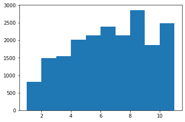

```python
plt.hist(data = new_df, x = "ProsperScore"); # discrete quantitative variable
```

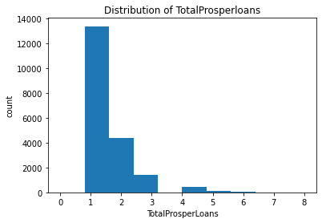

```python
# using the histogram to understand the distribution of the values in TotalProsperloans
plt.hist(data = new_df , x = "TotalProsperLoans");
plt_labels('TotalProsperLoans','count', 'Distribution of TotalProsperloans')
```

The distribution of the TOtalProsperloans seems to be skewed to the right this means that the range (of the means) of the values seems to exist across a particular space in the dataset

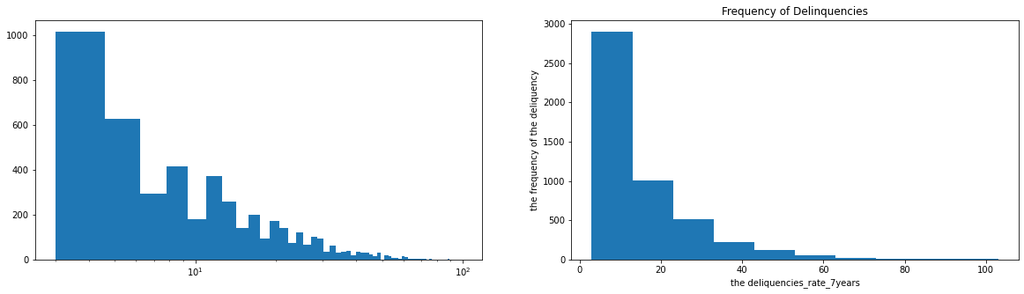

```python
# checking the deliquencies rate for the borrower in the last 7 years

#plotting numerical values that are
plt.figure(figsize=[20,5])
plt.subplot(1,2,1)
bin = np.arange(new_df["DelinquenciesLast7Years"].min()+3,new_df["DelinquenciesLast7Years"].max()+1.6,1.6 )
plt.hist(new_df["DelinquenciesLast7Years"], bins = bin )
plt.xscale("log");

plt.subplot(1,2,2)
bin = np.arange(new_df["DelinquenciesLast7Years"].min()+3,new_df["DelinquenciesLast7Years"].max()+10,10 )
plt.hist(new_df["DelinquenciesLast7Years"], bins = bin )
plt_labels("the deliquencies_rate_7years","the frequency of the deliquency", "Frequency of Delinquencies")
```

**Insight**

- From the above plot we can see that the range of values is skewed to the right.

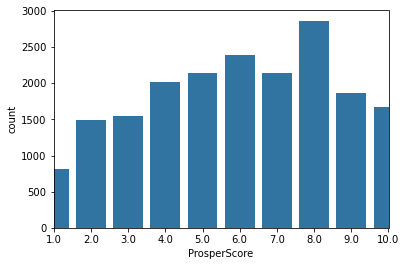

```python
# lets check the no of proper score rating  for every loans in the dataset
color_fav = sb.color_palette()[0]
sb.countplot(data = new_df , x = "ProsperScore",color= color_fav)
plt.xlim([0,9]);
```

This dataset also contains outliers which is 11. we can decide to drop it., we decided to limit the distribution to only range from 1 from 10

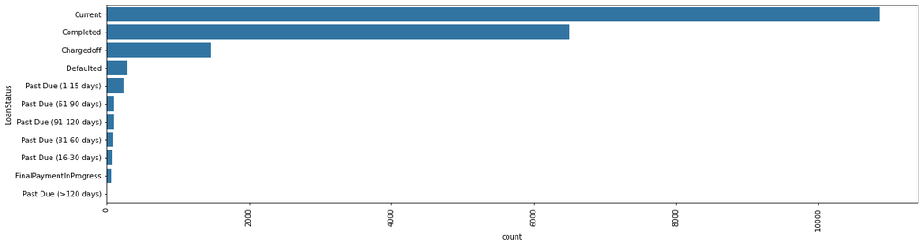

```python
#lets check for categorical variable for loanstatus, to know the count of loan status  in the distribution.
# ie lets know the number of loans that has been defaulted, or past due date.
order_index = new_df["LoanStatus"].value_counts().index
order_index_occupation = new_df["Occupation"].value_counts().index

plt.figure(figsize=[20,5])
#plt.subplot(2,1,1)
sb.countplot(data = new_df , y = "LoanStatus", order=order_index, color= color_fav)
plt.xticks(rotation = 90);
```

So we can see that the current loan is so much and has the highest range of values so there are alot of people on current loan.

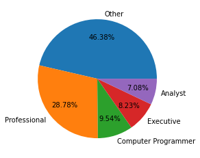

```python
# lets try to create a pie chart to visualize the occupation categories
occuptan_list = new_df["Occupation"].value_counts()[:5]
occupatn_index = occuptan_list.index

plt.pie(occuptan_list, labels= occupatn_index,pctdistance= 0.7 , autopct = "%.2f%%");
```